# Analysis of US Flight Data for 2018-2019 from Bureau of Transportation Statistics

## by (Mohammed Almahfoudh)

## Investigation Overview

The purpose of this project is to invistigate the data on flights in the US for two years period (2018-2019), and to drive an insight for a number of factors including:

- Overall flight activity
- Flight cancellation
- Flight delays
- Flight operators

## Dataset Overview

The data was extracted from the Bureau of Transportation Statistics database, and includes 29 data columns similar to the ones used for the Statistical Computing Statistical Graphics in Data Expo ‘09.

## 1. Flight Operators Distribution

As a first data point, we looked at the list of Flight Operators in the US based on the dataset. This chart will give us an indicator of what airlines have the most of the air traffic in our selected period. SouthWest, Delta, American Airlines, SkyWest, and United Airlines are taking the majority of the air traffic, respectively.

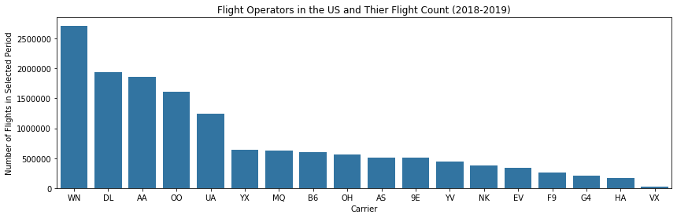

```python
clr = sns.color_palette()[0]
top_airline=df['OP_UNIQUE_CARRIER'].value_counts().index
plt.figure(figsize=(14, 4))
sns.countplot(data=df,x='OP_UNIQUE_CARRIER',color=clr,order=top_airline)
plt.title("Flight Operators in the US and Thier Flight Count (2018-2019)")
plt.xlabel("Carrier")
plt.ylabel("Number of Flights in Selected Period");
```

## 2. Flight Durations Distribution

After looking at the carriers, we looked at the distribution of the flights duration in the slected period. We can see from the chart that most of the flights last for less than 200 minutes, which can be explained by that two of the top 5 airlines in flight count do short trips and are economical in nature. (Flights lasting longer than 500 minutes are excluded)

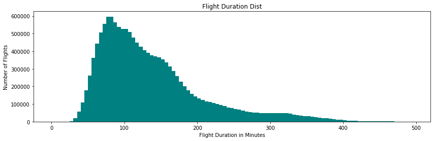

```python
bins=np.arange(0,500,5)
plt.figure(figsize=(14, 4))
plt.hist(data=df,x='ACTUAL_ELAPSED_TIME',bins=bins,color='teal')
plt.title('Flight Duration Dist')
plt.xlabel('Flight Duration in Minutes')
plt.ylabel('Number of Flights');
```

## 3. Flight Durations Look for The Top 5 Airlines

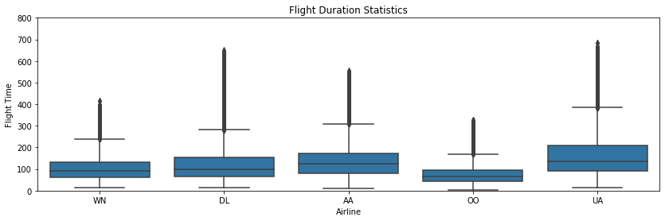

```python
plt.figure(figsize=(14, 4))
h=sns.boxplot(data=df,x='OP_UNIQUE_CARRIER',y='AIR_TIME',color=clr,order=top_airline);
h.set(ylim=(0,800),xlim=(-0.5,4.5))
plt.title('Flight Duration Statistics')
plt.xlabel('Airline')
plt.ylabel('Flight Time');
```

## 4. A Look at Overall Cancellation

he chart showed interesting pattern in cancellation for the two year sample we have. There is a high cancellation in both years in specific months such January (due to snow perhaps?), and June-August. Some months do vary between the years which is interesting, it may indicate special events during that specific year.

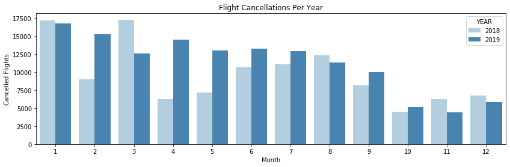

```python
cancelled=df.query('CANCELLED==1') #filtering tothe cancelled numbers only
plt.figure(figsize=(14, 4))
sns.countplot(data = cancelled, x = 'MONTH', hue = 'YEAR', palette = 'Blues');
plt.title('Flight Cancellations Per Year')
plt.xlabel('Month')
plt.ylabel('Cancelled Flights');
```

## 5. Flight Cancellation Across Months/Years in Relation to Cancellation Type

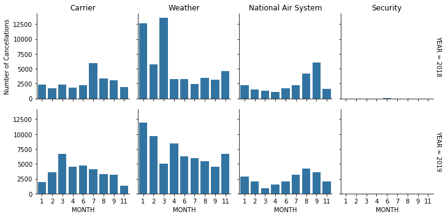

```python
g = sns.FacetGrid(data = cancelled, col = 'CANCELLATION_CODE', row = 'YEAR', size = 2.5,
                margin_titles = True,col_order=('A','B','C','D'))
g.map(sns.countplot,'MONTH');
axes = g.axes.flatten()
axes[0].set_title("Carrier")
axes[1].set_title("Weather")
axes[2].set_title("National Air System")
axes[3].set_title("Security")
axes[0].set_ylabel("Number of Cancellations");
```

## 6. Flight Distance-Duration Plot Across the Years for Top 5 Airlines by Traffic

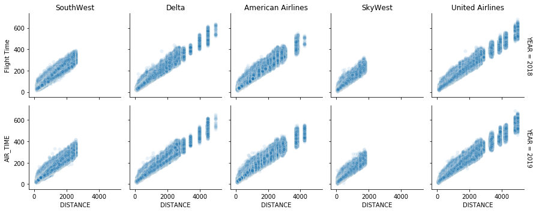

```python
airlines=('WN','DL','AA','OO','UA')
top_5=df.query('OP_UNIQUE_CARRIER in @airlines')
g = sns.FacetGrid(data = top_5, col = 'OP_UNIQUE_CARRIER', row = 'YEAR', height = 2.5,
                margin_titles = True,col_order=airlines)
g.map(sns.scatterplot,'DISTANCE','AIR_TIME',alpha=0.1)
axes = g.axes.flatten()
axes[0].set_title("SouthWest")
axes[1].set_title("Delta")
axes[2].set_title("American Airlines")
axes[3].set_title("SkyWest")
axes[4].set_title("United Airlines")
axes[0].set_ylabel("Flight Time");
```